# Fitting State-Space Models

Predicting Salmon Returns

WA-BC AFS Meeting Spokane, WA 29 April 2024

# Introduction

Many problems in environmental science can be addressed with state-space models and we’ve already seen a few examples of some simple models. This lab will introduce you to fitting univariate state-space models with the {MARSS} package. Notably, {MARSS} follows the same notation for defining state-space models as we would write on a whiteboard. Also, because {MARSS} was designed to fit mutlivariate state-space models, each of the model elements must be a `matrix` class. This also applies to scalar values such that they’re not `numeric` or `integer`.

# Gompertz model

We’ll begin by simulating a true state of nature and then corrupting it with some observation error to produce the “data”. Specifically, we’ll use a discrete-time Gompertz model of density-dependent growth. Recall that the size of a population at time $(N_t)$ is given by

$$N_t = N_{t-1} ~ \exp(u ~ + ~ (b - 1) \log(N_{t-1}))\exp(w _t)$$

Taking the log of both sides and substituting $x_t$ for $\log(N_t)$

$$\begin{align}
\log(N_t) & = \log(N_{t-1}) + u + (b - 1) \log(N_{t-1}) + w_t \\
& \Downarrow \\
x_t &= x_{t-1} + u + (b - 1) x_{t-1} + w_t \\
&= x_{t-1} + u + b x_{t-1} - x_{t-1} + w_t \\
&= u + b x_{t-1} + w_t
\end{align}$$

We generally assume the process errors are Gaussian, such that our full state model is our familiar AR(1) process

$$x_t = u + b x_{t-1} + w_t \\
~ \\
w_t \sim \text{N}(0, q)$$

**Note:** It’s very difficult to estimate both $u$ and $b$, so we’ll assume $u$ = 0.

## Initial state

So far we have largely ignored an important part of our model definition. Because our state model is an autoregressive process, we must define the initial state when $t$ = 0 $(x_0)$. In theory, $x_0$ is assumed to be a random effect with unknown mean and variance, such that

$$x_0 \sim \text{N}(\pi,\lambda)$$

In practice, however, estimating both $\pi$ and $\lambda$ is nearly impossible, so the default is to treat $x_0$ as a fixed (but unknown) effect, such that

$$x_0 \sim \text{N}(\pi,0).$$

# Simulate some data

**Task:** Use a `for()` loop to simulate from an AR(1) state model.

```r
## number of time steps
TT <- 40

## strength of density-dependence (0 < b < 1)
bb <- 0.5

## time series of process errors with SD = 1
ww <- rnorm(TT, 0, 1)

## initialize state & set x0 = w0
xx <- ww

## loop over time steps
for(t in 2:TT) {
  xx[t] <- bb * xx[t-1] + ww[t]
}
```

**Task:** Add some observation error to the true state.

```r
## obs errors with SD = 0.5
vv <- rnorm(TT, 0, 0.5)

## obs data
yy <- xx + vv
```

# Fitting models with {MARSS}

The workhorse function in the {MARSS} package that allows us to fit state-state models is `MARSS()`, which has four important arguments (two are required):

```r
MARSS(y, model = NULL, inits = NULL, control = NULL, ...)
```

- `y` is an $n \times T$ `matrix` of data (observations)
- `model` is a `list` that defines the state-space model in terms of parameters to be estimated
- `inits` [*optional*] is a `list` of initial values for parameters to be estimated
- `control` [*optional*] is a `list` of options for controlling fitting algorithms, setting tolerance & convergence parameters, etc

**Tip:** Type `?MARSS` at the command prompt to view the help file. You can also see the detailed user guide [here](https://cran.r-project.org/web/packages/MARSS/vignettes/UserGuide.pdf).

## Defining the model for `MARSS()`

`MARSS()` uses an expanded form of state-space model, such that our Gompertz model

$$\begin{align}
x_t &= b x_{t-1} + w_t \\
y_t &= x_t + v_t
\end{align}$$
instead becomes

$$\begin{align}
x_t &= b x_{t-1} + u + w_t \\
y_t &= Z x_t + a + v_t
\end{align}$$

with $u = 0$, $Z = 1$, and $a = 0$.

**Tip:** `MARSS()` works with the `matrix` class in R, so we have to define any scalar as a $1 \times 1$ matrix.

**Task:** Define the model list with matrices for the known and estimated model parameters, including the variance(s) of the process and/or observation errors. You can skip the definition of the initial state `x0` because `MARSS()` will do this for us.

```r
mod_list <- list(
  ## state model
  B = matrix("b"), # AR(1) parameter
  U = matrix(0),   # bias or intrinsic growth
  Q = matrix("q"), # variance of the process errors
  ## obs model
  Z = matrix(1),   # maps the states onto the observation
  A = matrix(0),   # sampling bias/offset
  R = matrix("r")  # variance of the obs errors
  )
```

**Note:** `MARSS()` uses uppercase letters in its model definition. You will get an error if you try lowercase letters.

**Task:** Define the data as a $1$ (rows) $\times$ $T$ (cols) matrix.

```r
## define the data as an N (rows) x T (cols) matrix
YY <- matrix(yy, nrow = 1, ncol = TT)
```

**Task:** Ignore the `inits` and `control` arguments for now and fit the model.

```r
## load MARSS package
library(MARSS)

## fit the model
mod_fit <- MARSS(y = YY, model = mod_list)
```

```
## Success! algorithm run for 15 iterations. abstol and log-log tests passed.
## Alert: conv.test.slope.tol is 0.5.
## Test with smaller values (<0.1) to ensure convergence.
##
## MARSS fit is
## Estimation method: kem
## Convergence test: conv.test.slope.tol = 0.5, abstol = 0.001
## Algorithm ran 15 (=minit) iterations and convergence was reached.
## Log-likelihood: -56.66821
## AIC: 121.3364   AICc: 122.4793
##
##       Estimate
## R.r      0.731
## B.b      0.443
## Q.q      0.229
## x0.x0    1.646
## Initial states (x0) defined at t=0
##
## Standard errors have not been calculated.
## Use MARSSparamCIs to compute CIs and bias estimates.
```

## Interpreting `MARSS()` output

`MARSS()` returns a block of information when it’s finished that contains some useful information, but also lacks some other stuff that we’ll extract below.

**Tip:** The first block of information tells us if all of the parameters converged within the default number of iterations (500) (`Success!`). It also suggests we try more conservative convergence limits, but this can largely be ignored.

[output not shown]

**Tip:** The second block tells us

- the method used for fitting (`kem` here)
- the convergence test parameters
- number of iterations before convergence
- the log-likelihood and associated information scores

[output not shown]

**Tip:** The third block lists the point estimates of the model parameters corresponding to the model list (`mod_list` above), including the initial state `x0`. By default `MARSS()` appends the model list item (eg, `Q`) and the specific parameter as defined by the user (eg, `q`). When we fit multivariate models, there will be multiple entries for those list items containing multiple parameters (eg, `Q.var`, `Q.cov`).

[output not shown]

**Tip:** The last block tells you that standard errors of the estimated parameters have not been estimated and that you can use the `MARSSparamCIs()` function to estimate them.

```
## Standard errors have not been calculated.
## Use MARSSparamCIs to compute CIs and bias estimates.
```

# Extracting info from {MARSS}

Although `MARSS()` returns some useful information after execution, the `MARSS` object also contains a lot of other important information that we can extract and act upon. Specifically, when assigned to an object, `MARSS()` returns a long `list` containing details about the model structure, control parameters, estimated parameters, hidden states and their standard errors.

**Tip:** Type `str(MARSS_object)` where `MARSS_object` is the object you assigned to the `MARSS()` call (ie, `mod_fit` above) to see a detailed outline of the list structure.

## Estimated states

Fitted values are stored in an $N \times T$ matrix (here $N = 1$) accessed with `$states`. The standard errors of the estimated states are stored in an $N \times T$ matrix accessed with `$states.se`.

**Task:** Extract the estimated state and its standard error.

**Tip:** It’s often easier to transpose the state(s) after extracting them for use in plotting or other comparisons.

```r
## T x 1 (transposed) vector of states
mod_fits <- mod_fit$states |> t()

## T x 1 (transposed) vector of SE's
mod_fits_SE <- mod_fit$states.se |> t()
```

## Model parameters

We can extract the parameters directly from a fitted MARSS model object rather than having to transcribe or copy/paste them from the output.

**Tip:** We can use the `coef()` function to extract $b$ from the `MARSS()` fitted object.

**Task:** Use `coef()` to extract $b$.

```r
## get the estimated parameters
params_est <- coef(mod_fit, type = "vector")

## get `b` (strength of density dependence)
params_est["B.b"] |> round(2)
```

```
##  B.b
## 0.44
```

# Approximate confidence intervals

We can estimate a [(1 - $\alpha$) $\times$ 100]% confidence interval around the estimated states as

$$\hat{x} ~ \pm ~ t_{1 - \alpha/2} \times \text{SE}(\hat{x})$$

**Tip:** You can get values from the t-distribution with the function `qt()`. Type `?qt` for more information.

```r
## upper 95% CI
mod_fits_CI_hi <- mod_fits + qt(p = 0.975, df = TT - 1) * mod_fits_SE

## lower 95% CI
mod_fits_CI_lo <- mod_fits - qt(p = 0.975, df = TT - 1) * mod_fits_SE
```

# Plotting the states & SE

It’s common to plot the estimated state and some uncertainty about it (i.e., standard error, confidence interval), along with the data. Here are some examples using the base functions `plot()` and `lines()`. Similar plots could easily be made with `ggplot()` as well.

## Model fit and true states

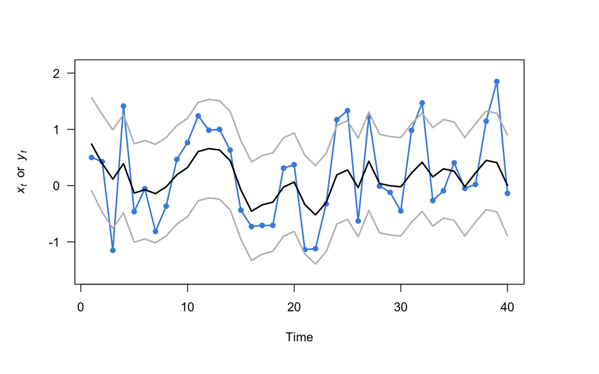

```r
par(mai = c(1.2, 1, 0.3, 0), omi = c(0, 0, 0.5, 1))
plot.ts(xx, lwd = 2, type = "o", pch = 16, col = "#488fdf",
        las = 1, ylim = c(min(xx,yy), max(xx,yy)),
        ylab = expression(italic(x[t])~~or~~italic(y[t])))
# lines(yy, lwd = 2, type = "o", pch = 16, cex = 1.5, col = "#844870")
lines(mod_fits, lwd = 2, type = "l", cex = 1.5, col = "black")
lines(mod_fits_CI_hi, lwd = 2, type = "l", cex = 1.5, col = "gray")
lines(mod_fits_CI_lo, lwd = 2, type = "l", cex = 1.5, col = "gray")
```

## Model fit with observations only

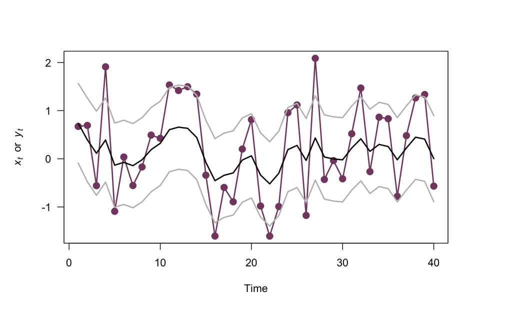

```r
par(mai = c(1.2, 1, 0.3, 0), omi = c(0, 0, 0.5, 1))
plot.ts(yy, lwd = 2, type = "o", pch = 16, cex = 1.5, col = "#844870",
        las = 1, ylim = c(min(xx,yy), max(xx,yy)),
        ylab = expression(italic(x[t])~~or~~italic(y[t])))
lines(mod_fits, lwd = 2, type = "l", cex = 1.5, col = "black")
lines(mod_fits_CI_hi, lwd = 2, type = "l", cex = 1.5, col = "gray")
lines(mod_fits_CI_lo, lwd = 2, type = "l", cex = 1.5, col = "gray")
```

# Model summaries

In addition to accessing the various aspects contained in the list of a fitted object of class `marssMLE` returned by `MARSS()`, you can use some summary functions to obtain parameter estimates and model fits. You can also get a set of standard plots of the model fits and diagnostics. Here are a few of the options:

- `coef(mod_fit)` to get the estimated parameters
- `tidy(mod_fit)` to get estimated parameters with CIs
- `fitted(mod_)` to get the model estimates of mean y
- `plot(mod_fit)` to view a series of base plots of the states, data, and diagnostics
- `ggplot2::autoplot(mod_fit)` to view a series of ggplots of the states, data, and diagnostics

# Model diagnostics

Just like other statistical models, state-space models come with their own set of assumptions. As such, it’s a good idea to examine some model diagnostics to see if the assumptions have been met. For the univariate state-space models we’re using here, the assumptions include the following:

- The errors ($w_t$ and $v_t$) are normally distributed
- The errors ($w_t$ and $v_t$) have constant variance
- The errors ($w_t$ and $v_t$) are independent

We can assess how well something fits a normal distribution via a q-q plot or `qqplot()`. We can use plots of the errors versus time to see if the variance changes. We can use the familiar autocorrelaction function `acf()` to assess whether the errors are independent over time.

**Tip:** The `plot()` and `ggplot2::autoplot()` functions produce useful diagnostic plots.

**Task:** Use either `plot()` or `ggplot2::autoplot()` to see how well our fitted model meets the assumptions.

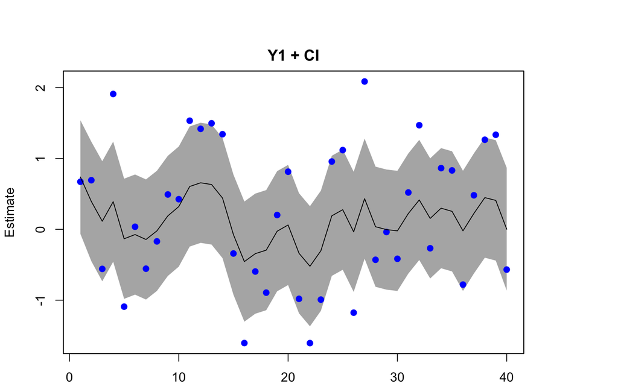

```
## plot type =  fitted.ytT  Observations with fitted values
## Hit <Return> to see next plot (q to exit):
```

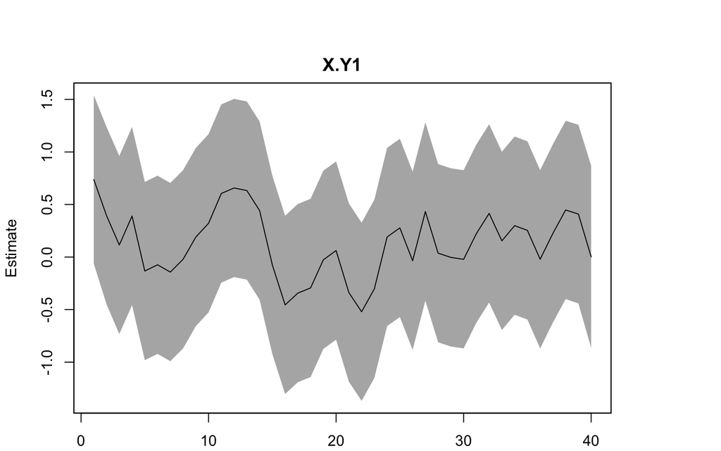

```
## plot type = xtT Estimated states
## Hit <Return> to see next plot (q to exit):
```

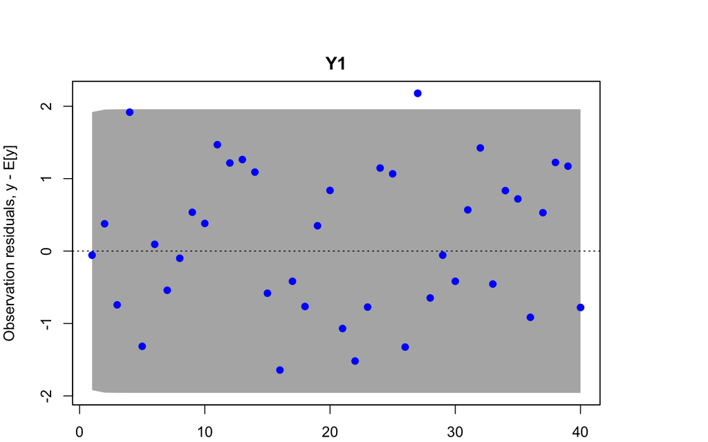

```
## plot type = model.resids.ytt1
## Hit <Return> to see next plot (q to exit):
```

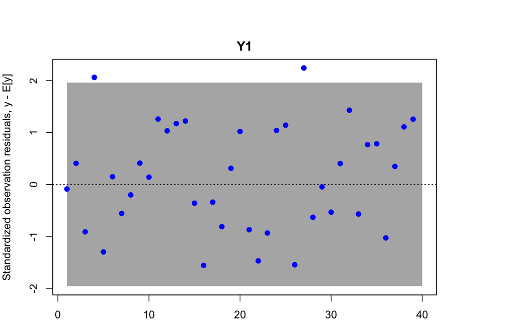

```
## plot type = std.model.resids.ytT
## Hit <Return> to see next plot (q to exit):
```

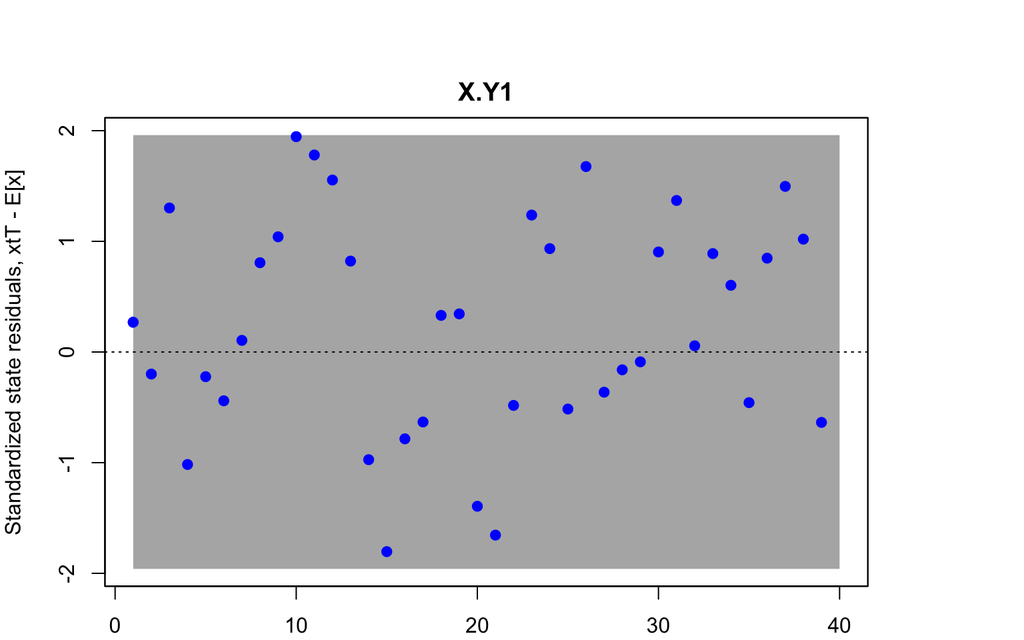

```
## plot type = std.state.resids.xtT
## Hit <Return> to see next plot (q to exit):
```

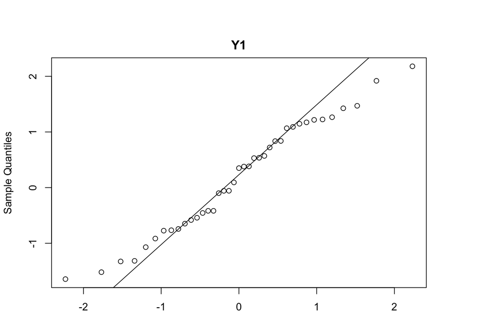

```
## plot type = qqplot.std.model.resids.ytt1
## Hit <Return> to see next plot (q to exit):
```

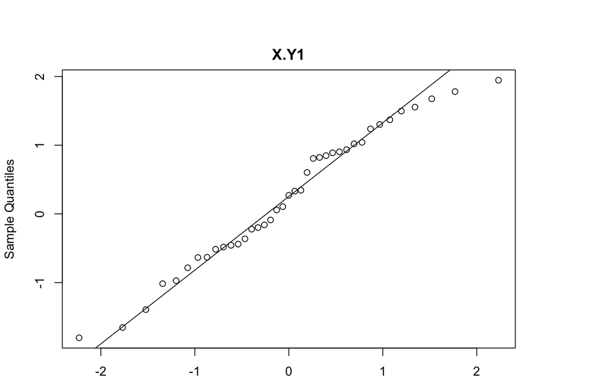

```
## plot type = qqplot.std.state.resids.xtT
## Hit <Return> to see next plot (q to exit):
```

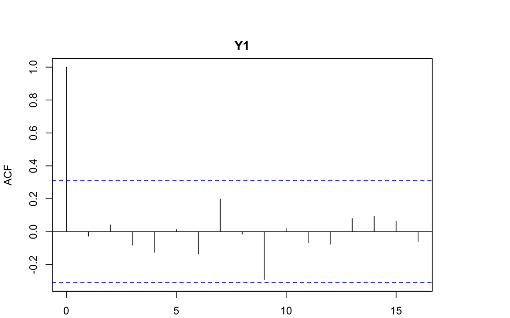

```
## plot type = acf.std.model.resids.ytt1
```

```r
## get summary & diagnostic plots
plot(mod_fit)
```

# Forecasting

Autoregressive models like the one we fit above can make good forecast models, especially if meaningful covariates can be included as well. The {MARSS} package uses a Kalman filtering algorithm for estimating model parameters, which generates three different forms of estimated states and observations for a discrete time series with $t = 1:T$:

1. *prediction*, conditioned on the data from $1:(t - 1)$;
2. *filtering*, conditioned on the data from $1:t$;
3. *smoothing*, conditioned on the data from $1:T$.

By default, the `MARSS()` function produces the smoothed estimates (or “smoothations”), but in a forecasting context we want estimates conditioned on the data from $1:(t - 1)$, not $1:T$.

**Tip:** We can use the `predict()` function to generate forecasts and associated uncertainty intervals.

**Task:** Get the one-step ahead forecasts for the observed data based on our state-space model, along with the 90% prediction intervals.

```r
## get forecasts and associated prediction interval
fY <- predict(mod_fit,                  # use the fitted model object
              level = 0.90,             # choose 90% for PI's
              type = "ytt1",            # shorthand for 1:(t-1)
              interval = "prediction")  # type of interval
```

**Tip:** We can use the `plot()` or `ggplot2::autoplot()` functions to plot forecasts and their associated uncertainty intervals along with the data.

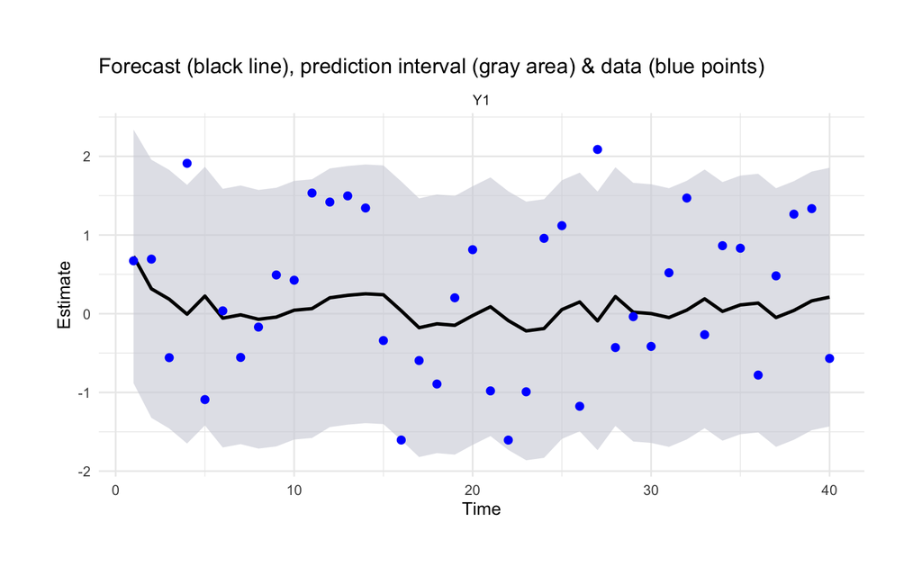

```r
## load ggplot
library(ggplot2)

## create plot
autoplot(fY, plot.par = list(theme = theme_minimal(), point.size = 2)) +
  ggtitle("Forecast (black line), prediction interval (gray area) & data (blue points)") +
  theme(plot.margin = unit(c(0.5, 0.5, 0.5, 0.5), "inches"))
```